# Risk Factor Analysis

## Outcome Variable

**Outcome Variable:** pers_wasted624

## Predictor Variables

**Intervention Variable:** ever_wasted06_noBW

**Adjustment Set:**

- sex
- arm
- enstunt
- month
- brthmon
- vagbrth
- single
- W_gagebrth
- W_birthwt
- W_birthlen
- W_mage
- W_mhtcm
- W_meducyrs
- W_feducyrs
- W_parity
- delta_month
- delta_brthmon
- delta_vagbrth
- delta_single
- delta_W_gagebrth
- delta_W_birthwt
- delta_W_birthlen
- delta_W_mage
- delta_W_mhtcm
- delta_W_meducyrs
- delta_W_feducyrs
- delta_W_parity

## Stratifying Variables

The analysis was stratified on these variable(s):

- studyid
- country

## Data Summary

| studyid | country | ever_wasted06_noBW | pers_wasted624 | n_cell | n |
| --- | --- | --- | --- | --- | --- |
| ki0047075b-MAL-ED | BANGLADESH | 0 | 0 | 210 | 238 |
| ki0047075b-MAL-ED | BANGLADESH | 0 | 1 | 11 | 238 |
| ki0047075b-MAL-ED | BANGLADESH | 1 | 0 | 10 | 238 |
| ki0047075b-MAL-ED | BANGLADESH | 1 | 1 | 7 | 238 |
| ki0047075b-MAL-ED | BRAZIL | 0 | 0 | 193 | 201 |
| ki0047075b-MAL-ED | BRAZIL | 0 | 1 | 1 | 201 |
| ki0047075b-MAL-ED | BRAZIL | 1 | 0 | 7 | 201 |
| ki0047075b-MAL-ED | BRAZIL | 1 | 1 | 0 | 201 |
| ki0047075b-MAL-ED | INDIA | 0 | 0 | 180 | 229 |
| ki0047075b-MAL-ED | INDIA | 0 | 1 | 13 | 229 |
| ki0047075b-MAL-ED | INDIA | 1 | 0 | 26 | 229 |
| ki0047075b-MAL-ED | INDIA | 1 | 1 | 10 | 229 |
| ki0047075b-MAL-ED | NEPAL | 0 | 0 | 217 | 232 |
| ki0047075b-MAL-ED | NEPAL | 0 | 1 | 0 | 232 |
| ki0047075b-MAL-ED | NEPAL | 1 | 0 | 14 | 232 |
| ki0047075b-MAL-ED | NEPAL | 1 | 1 | 1 | 232 |
| ki0047075b-MAL-ED | PERU | 0 | 0 | 257 | 264 |
| ki0047075b-MAL-ED | PERU | 0 | 1 | 2 | 264 |
| ki0047075b-MAL-ED | PERU | 1 | 0 | 5 | 264 |
| ki0047075b-MAL-ED | PERU | 1 | 1 | 0 | 264 |
| ki0047075b-MAL-ED | SOUTH AFRICA | 0 | 0 | 246 | 257 |
| ki0047075b-MAL-ED | SOUTH AFRICA | 0 | 1 | 0 | 257 |
| ki0047075b-MAL-ED | SOUTH AFRICA | 1 | 0 | 10 | 257 |
| ki0047075b-MAL-ED | SOUTH AFRICA | 1 | 1 | 1 | 257 |
| ki0047075b-MAL-ED | TANZANIA, UNITED REPUBLIC OF | 0 | 0 | 236 | 244 |
| ki0047075b-MAL-ED | TANZANIA, UNITED REPUBLIC OF | 0 | 1 | 0 | 244 |
| ki0047075b-MAL-ED | TANZANIA, UNITED REPUBLIC OF | 1 | 0 | 8 | 244 |
| ki0047075b-MAL-ED | TANZANIA, UNITED REPUBLIC OF | 1 | 1 | 0 | 244 |
| ki1000108-CMC-V-BCS-2002 | INDIA | 0 | 0 | 237 | 350 |
| ki1000108-CMC-V-BCS-2002 | INDIA | 0 | 1 | 5 | 350 |

[output cut: 118 more lines]

The following strata were considered:

- studyid: ki0047075b-MAL-ED, country: BANGLADESH
- studyid: ki0047075b-MAL-ED, country: BRAZIL
- studyid: ki0047075b-MAL-ED, country: INDIA
- studyid: ki0047075b-MAL-ED, country: NEPAL
- studyid: ki0047075b-MAL-ED, country: PERU
- studyid: ki0047075b-MAL-ED, country: SOUTH AFRICA
- studyid: ki0047075b-MAL-ED, country: TANZANIA, UNITED REPUBLIC OF
- studyid: ki1000108-CMC-V-BCS-2002, country: INDIA
- studyid: ki1000108-IRC, country: INDIA
- studyid: ki1000109-EE, country: PAKISTAN
- studyid: ki1000109-ResPak, country: PAKISTAN
- studyid: ki1000304-VITAMIN-A, country: INDIA
- studyid: ki1000304b-SAS-CompFeed, country: INDIA
- studyid: ki1000304b-SAS-FoodSuppl, country: INDIA
- studyid: ki1017093-NIH-Birth, country: BANGLADESH
- studyid: ki1017093b-PROVIDE, country: BANGLADESH
- studyid: ki1017093c-NIH-Crypto, country: BANGLADESH
- studyid: ki1066203-TanzaniaChild2, country: TANZANIA, UNITED REPUBLIC OF
- studyid: ki1101329-Keneba, country: GAMBIA
- studyid: ki1112895-Burkina Faso Zn, country: BURKINA FASO
- studyid: ki1112895-Guatemala BSC, country: GUATEMALA
- studyid: ki1113344-GMS-Nepal, country: NEPAL
- studyid: ki1114097-CMIN, country: BANGLADESH
- studyid: ki1114097-CMIN, country: BRAZIL
- studyid: ki1114097-CMIN, country: GUINEA-BISSAU
- studyid: ki1114097-CMIN, country: PERU
- studyid: ki1114097-CONTENT, country: PERU
- studyid: ki1119695-PROBIT, country: BELARUS
- studyid: ki1126311-ZVITAMBO, country: ZIMBABWE
- studyid: ki1135781-COHORTS, country: GUATEMALA
- studyid: ki1135781-COHORTS, country: INDIA
- studyid: ki1135781-COHORTS, country: PHILIPPINES
- studyid: ki1148112-iLiNS-DOSE, country: MALAWI
- studyid: ki1148112-iLiNS-DYAD-M, country: MALAWI
- studyid: ki1148112-LCNI-5, country: MALAWI
- studyid: kiGH5241-JiVitA-3, country: BANGLADESH
- studyid: kiGH5241-JiVitA-4, country: BANGLADESH

### Dropped Strata

Some strata were dropped due to rare outcomes:

- studyid: ki0047075b-MAL-ED, country: BRAZIL
- studyid: ki0047075b-MAL-ED, country: NEPAL
- studyid: ki0047075b-MAL-ED, country: PERU
- studyid: ki0047075b-MAL-ED, country: SOUTH AFRICA
- studyid: ki0047075b-MAL-ED, country: TANZANIA, UNITED REPUBLIC OF
- studyid: ki1000304b-SAS-FoodSuppl, country: INDIA
- studyid: ki1112895-Burkina Faso Zn, country: BURKINA FASO
- studyid: ki1112895-Guatemala BSC, country: GUATEMALA
- studyid: ki1114097-CMIN, country: BRAZIL
- studyid: ki1114097-CMIN, country: PERU
- studyid: ki1114097-CONTENT, country: PERU
- studyid: ki1148112-iLiNS-DOSE, country: MALAWI
- studyid: ki1148112-iLiNS-DYAD-M, country: MALAWI
- studyid: ki1148112-LCNI-5, country: MALAWI

## Methods Detail

We’re interested in the causal parameters $E[Y_a]$ for all values of $a \in \mathcal{A}$. These parameters represent the mean outcome if, possibly contrary to fact, we intervened to set all units to have $A=a$. Under the randomization and positivity assumptions, these are identified by the statistical parameters $\psi_a=E_W[E_{Y|A,W}(Y|A=a,W)]$. In addition, we’re interested in the mean of $Y$, $E[Y]$ under no intervention (the observed mean). We will estimate these parameters by using SuperLearner to fit the relevant likelihood factors – $E_{Y|A,W}(Y|A=a,W)$ and $p(A=a|W)$, and then updating our likelihood fit using a joint TMLE.

For unadjusted analyses ($W=\{\}$), initial likelihoods were estimated using Lrnr_glm to estimate the simple $E(Y|A)$ and Lrnr_mean to estimate $p(A)$. For adjusted analyses, a small library containing Lrnr_glmnet, Lrnr_xgboost, and Lrnr_mean was used.

Having estimated these parameters, we will then use the delta method to estimate relative risks and attributable risks relative to a prespecified baseline level of $A$.

# Results Detail

## Results Plots

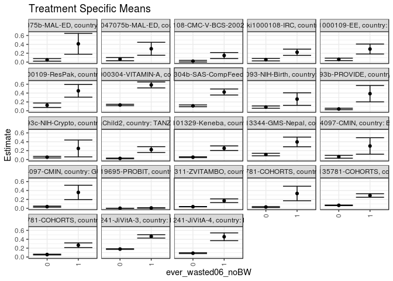

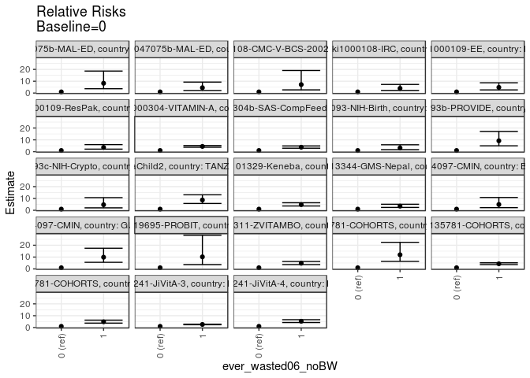

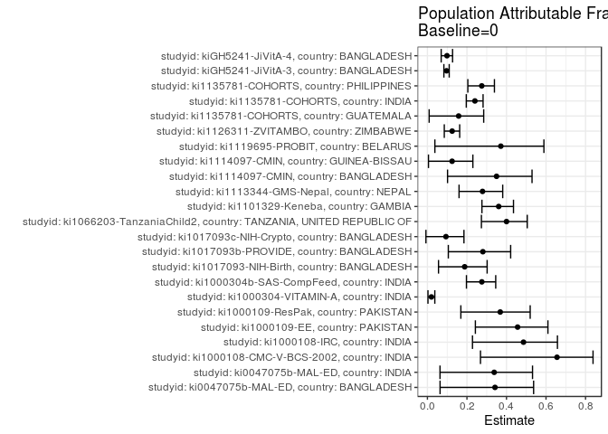

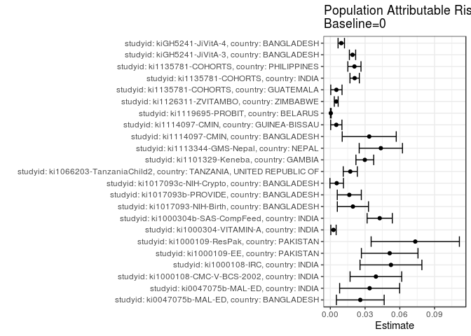

## Results Table

### Parameter: TSM

| studyid | country | intervention_level | baseline_level | estimate | ci_lower | ci_upper |
| --- | --- | --- | --- | --- | --- | --- |
| ki0047075b-MAL-ED | BANGLADESH | 0 | NA | 0.0497738 | 0.0210408 | 0.0785067 |
| ki0047075b-MAL-ED | BANGLADESH | 1 | NA | 0.4117647 | 0.1773213 | 0.6462081 |
| ki0047075b-MAL-ED | INDIA | 0 | NA | 0.0665015 | 0.0309678 | 0.1020351 |
| ki0047075b-MAL-ED | INDIA | 1 | NA | 0.3000650 | 0.1538088 | 0.4463211 |
| ki1000108-CMC-V-BCS-2002 | INDIA | 0 | NA | 0.0206612 | 0.0027136 | 0.0386087 |
| ki1000108-CMC-V-BCS-2002 | INDIA | 1 | NA | 0.1481481 | 0.0810535 | 0.2152428 |
| ki1000108-IRC | INDIA | 0 | NA | 0.0553496 | 0.0274881 | 0.0832111 |
| ki1000108-IRC | INDIA | 1 | NA | 0.2219411 | 0.1520068 | 0.2918754 |
| ki1000109-EE | PAKISTAN | 0 | NA | 0.0610728 | 0.0335280 | 0.0886176 |
| ki1000109-EE | PAKISTAN | 1 | NA | 0.2940328 | 0.1818828 | 0.4061828 |
| ki1000109-ResPak | PAKISTAN | 0 | NA | 0.1257281 | 0.0753790 | 0.1760773 |
| ki1000109-ResPak | PAKISTAN | 1 | NA | 0.4503397 | 0.3076576 | 0.5930217 |
| ki1000304-VITAMIN-A | INDIA | 0 | NA | 0.1312877 | 0.1161493 | 0.1464261 |
| ki1000304-VITAMIN-A | INDIA | 1 | NA | 0.5833333 | 0.5163711 | 0.6502956 |
| ki1000304b-SAS-CompFeed | INDIA | 0 | NA | 0.1122951 | 0.0918542 | 0.1327360 |
| ki1000304b-SAS-CompFeed | INDIA | 1 | NA | 0.4235780 | 0.3557471 | 0.4914088 |
| ki1017093-NIH-Birth | BANGLADESH | 0 | NA | 0.0839569 | 0.0582662 | 0.1096475 |
| ki1017093-NIH-Birth | BANGLADESH | 1 | NA | 0.2641721 | 0.1226527 | 0.4056915 |
| ki1017093b-PROVIDE | BANGLADESH | 0 | NA | 0.0419682 | 0.0254293 | 0.0585070 |
| ki1017093b-PROVIDE | BANGLADESH | 1 | NA | 0.3861407 | 0.2020299 | 0.5702515 |
| ki1017093c-NIH-Crypto | BANGLADESH | 0 | NA | 0.0531609 | 0.0364815 | 0.0698404 |
| ki1017093c-NIH-Crypto | BANGLADESH | 1 | NA | 0.2500000 | 0.0600946 | 0.4399054 |
| ki1066203-TanzaniaChild2 | TANZANIA, UNITED REPUBLIC OF | 0 | NA | 0.0258028 | 0.0183507 | 0.0332549 |
| ki1066203-TanzaniaChild2 | TANZANIA, UNITED REPUBLIC OF | 1 | NA | 0.2243221 | 0.1589699 | 0.2896743 |
| ki1101329-Keneba | GAMBIA | 0 | NA | 0.0528167 | 0.0427537 | 0.0628796 |
| ki1101329-Keneba | GAMBIA | 1 | NA | 0.2545688 | 0.2023330 | 0.3068046 |
| ki1113344-GMS-Nepal | NEPAL | 0 | NA | 0.1127565 | 0.0840543 | 0.1414587 |
| ki1113344-GMS-Nepal | NEPAL | 1 | NA | 0.3965579 | 0.2882208 | 0.5048950 |
| ki1114097-CMIN | BANGLADESH | 0 | NA | 0.0624207 | 0.0304797 | 0.0943617 |
| ki1114097-CMIN | BANGLADESH | 1 | NA | 0.3056390 | 0.1204360 | 0.4908420 |
| ki1114097-CMIN | GUINEA-BISSAU | 0 | NA | 0.0361727 | 0.0235499 | 0.0487955 |
| ki1114097-CMIN | GUINEA-BISSAU | 1 | NA | 0.3571429 | 0.1956767 | 0.5186091 |
| ki1119695-PROBIT | BELARUS | 0 | NA | 0.0006582 | 0.0000015 | 0.0013150 |
| ki1119695-PROBIT | BELARUS | 1 | NA | 0.0067114 | 0.0018519 | 0.0115710 |
| ki1126311-ZVITAMBO | ZIMBABWE | 0 | NA | 0.0355359 | 0.0314994 | 0.0395723 |
| ki1126311-ZVITAMBO | ZIMBABWE | 1 | NA | 0.1701172 | 0.1282364 | 0.2119979 |
| ki1135781-COHORTS | GUATEMALA | 0 | NA | 0.0278746 | 0.0167840 | 0.0389651 |
| ki1135781-COHORTS | GUATEMALA | 1 | NA | 0.3333333 | 0.1698433 | 0.4968234 |
| ki1135781-COHORTS | INDIA | 0 | NA | 0.0663637 | 0.0594361 | 0.0732914 |
| ki1135781-COHORTS | INDIA | 1 | NA | 0.2880646 | 0.2484151 | 0.3277141 |
| ki1135781-COHORTS | PHILIPPINES | 0 | NA | 0.0548618 | 0.0459030 | 0.0638206 |
| ki1135781-COHORTS | PHILIPPINES | 1 | NA | 0.2649917 | 0.2122111 | 0.3177723 |
| kiGH5241-JiVitA-3 | BANGLADESH | 0 | NA | 0.1785682 | 0.1711026 | 0.1860339 |
| kiGH5241-JiVitA-3 | BANGLADESH | 1 | NA | 0.4645992 | 0.4266414 | 0.5025571 |
| kiGH5241-JiVitA-4 | BANGLADESH | 0 | NA | 0.0860373 | 0.0758026 | 0.0962720 |
| kiGH5241-JiVitA-4 | BANGLADESH | 1 | NA | 0.4559715 | 0.3687832 | 0.5431598 |

### Parameter: E(Y)

| studyid | country | intervention_level | baseline_level | estimate | ci_lower | ci_upper |
| --- | --- | --- | --- | --- | --- | --- |
| ki0047075b-MAL-ED | BANGLADESH | NA | NA | 0.0756303 | 0.0419679 | 0.1092926 |
| ki0047075b-MAL-ED | INDIA | NA | NA | 0.1004367 | 0.0614207 | 0.1394527 |
| ki1000108-CMC-V-BCS-2002 | INDIA | NA | NA | 0.0600000 | 0.0350842 | 0.0849158 |
| ki1000108-IRC | INDIA | NA | NA | 0.1076923 | 0.0768872 | 0.1384974 |
| ki1000109-EE | PAKISTAN | NA | NA | 0.1123288 | 0.0798897 | 0.1447679 |
| ki1000109-ResPak | PAKISTAN | NA | NA | 0.1990741 | 0.1456997 | 0.2524484 |
| ki1000304-VITAMIN-A | INDIA | NA | NA | 0.1340000 | 0.1190668 | 0.1489332 |
| ki1000304b-SAS-CompFeed | INDIA | NA | NA | 0.1549509 | 0.1362795 | 0.1736222 |
| ki1017093-NIH-Birth | BANGLADESH | NA | NA | 0.1034483 | 0.0765382 | 0.1303583 |
| ki1017093b-PROVIDE | BANGLADESH | NA | NA | 0.0583333 | 0.0395643 | 0.0771024 |
| ki1017093c-NIH-Crypto | BANGLADESH | NA | NA | 0.0586592 | 0.0414351 | 0.0758833 |
| ki1066203-TanzaniaChild2 | TANZANIA, UNITED REPUBLIC OF | NA | NA | 0.0430220 | 0.0339104 | 0.0521337 |
| ki1101329-Keneba | GAMBIA | NA | NA | 0.0826027 | 0.0710097 | 0.0941956 |
| ki1113344-GMS-Nepal | NEPAL | NA | NA | 0.1563636 | 0.1259823 | 0.1867450 |
| ki1114097-CMIN | BANGLADESH | NA | NA | 0.0960000 | 0.0594095 | 0.1325905 |
| ki1114097-CMIN | GUINEA-BISSAU | NA | NA | 0.0413318 | 0.0281047 | 0.0545589 |
| ki1119695-PROBIT | BELARUS | NA | NA | 0.0010471 | 0.0002517 | 0.0018425 |
| ki1126311-ZVITAMBO | ZIMBABWE | NA | NA | 0.0406194 | 0.0363964 | 0.0448425 |
| ki1135781-COHORTS | GUATEMALA | NA | NA | 0.0331050 | 0.0212506 | 0.0449595 |
| ki1135781-COHORTS | INDIA | NA | NA | 0.0873555 | 0.0798578 | 0.0948531 |
| ki1135781-COHORTS | PHILIPPINES | NA | NA | 0.0756579 | 0.0657470 | 0.0855688 |
| kiGH5241-JiVitA-3 | BANGLADESH | NA | NA | 0.1977211 | 0.1902810 | 0.2051611 |
| kiGH5241-JiVitA-4 | BANGLADESH | NA | NA | 0.0954815 | 0.0850302 | 0.1059328 |

### Parameter: RR

| studyid | country | intervention_level | baseline_level | estimate | ci_lower | ci_upper |
| --- | --- | --- | --- | --- | --- | --- |
| ki0047075b-MAL-ED | BANGLADESH | 0 | 0 | 1.000000 | 1.000000 | 1.000000 |
| ki0047075b-MAL-ED | BANGLADESH | 1 | 0 | 8.272727 | 3.677204 | 18.611427 |
| ki0047075b-MAL-ED | INDIA | 0 | 0 | 1.000000 | 1.000000 | 1.000000 |
| ki0047075b-MAL-ED | INDIA | 1 | 0 | 4.512156 | 2.193467 | 9.281903 |
| ki1000108-CMC-V-BCS-2002 | INDIA | 0 | 0 | 1.000000 | 1.000000 | 1.000000 |
| ki1000108-CMC-V-BCS-2002 | INDIA | 1 | 0 | 7.170370 | 2.692106 | 19.098139 |
| ki1000108-IRC | INDIA | 0 | 0 | 1.000000 | 1.000000 | 1.000000 |
| ki1000108-IRC | INDIA | 1 | 0 | 4.009803 | 2.205666 | 7.289642 |
| ki1000109-EE | PAKISTAN | 0 | 0 | 1.000000 | 1.000000 | 1.000000 |
| ki1000109-EE | PAKISTAN | 1 | 0 | 4.814462 | 2.665297 | 8.696609 |
| ki1000109-ResPak | PAKISTAN | 0 | 0 | 1.000000 | 1.000000 | 1.000000 |
| ki1000109-ResPak | PAKISTAN | 1 | 0 | 3.581853 | 2.150194 | 5.966751 |
| ki1000304-VITAMIN-A | INDIA | 0 | 0 | 1.000000 | 1.000000 | 1.000000 |
| ki1000304-VITAMIN-A | INDIA | 1 | 0 | 4.443167 | 3.775988 | 5.228230 |
| ki1000304b-SAS-CompFeed | INDIA | 0 | 0 | 1.000000 | 1.000000 | 1.000000 |
| ki1000304b-SAS-CompFeed | INDIA | 1 | 0 | 3.772007 | 2.933413 | 4.850335 |
| ki1017093-NIH-Birth | BANGLADESH | 0 | 0 | 1.000000 | 1.000000 | 1.000000 |
| ki1017093-NIH-Birth | BANGLADESH | 1 | 0 | 3.146521 | 1.695413 | 5.839637 |
| ki1017093b-PROVIDE | BANGLADESH | 0 | 0 | 1.000000 | 1.000000 | 1.000000 |
| ki1017093b-PROVIDE | BANGLADESH | 1 | 0 | 9.200802 | 4.953428 | 17.090134 |
| ki1017093c-NIH-Crypto | BANGLADESH | 0 | 0 | 1.000000 | 1.000000 | 1.000000 |
| ki1017093c-NIH-Crypto | BANGLADESH | 1 | 0 | 4.702703 | 2.067355 | 10.697444 |
| ki1066203-TanzaniaChild2 | TANZANIA, UNITED REPUBLIC OF | 0 | 0 | 1.000000 | 1.000000 | 1.000000 |
| ki1066203-TanzaniaChild2 | TANZANIA, UNITED REPUBLIC OF | 1 | 0 | 8.693711 | 5.767861 | 13.103750 |
| ki1101329-Keneba | GAMBIA | 0 | 0 | 1.000000 | 1.000000 | 1.000000 |
| ki1101329-Keneba | GAMBIA | 1 | 0 | 4.819859 | 3.646703 | 6.370423 |
| ki1113344-GMS-Nepal | NEPAL | 0 | 0 | 1.000000 | 1.000000 | 1.000000 |
| ki1113344-GMS-Nepal | NEPAL | 1 | 0 | 3.516940 | 2.421822 | 5.107256 |
| ki1114097-CMIN | BANGLADESH | 0 | 0 | 1.000000 | 1.000000 | 1.000000 |
| ki1114097-CMIN | BANGLADESH | 1 | 0 | 4.896434 | 2.215185 | 10.823055 |
| ki1114097-CMIN | GUINEA-BISSAU | 0 | 0 | 1.000000 | 1.000000 | 1.000000 |
| ki1114097-CMIN | GUINEA-BISSAU | 1 | 0 | 9.873272 | 5.577368 | 17.478047 |
| ki1119695-PROBIT | BELARUS | 0 | 0 | 1.000000 | 1.000000 | 1.000000 |
| ki1119695-PROBIT | BELARUS | 1 | 0 | 10.195973 | 3.648746 | 28.491398 |
| ki1126311-ZVITAMBO | ZIMBABWE | 0 | 0 | 1.000000 | 1.000000 | 1.000000 |
| ki1126311-ZVITAMBO | ZIMBABWE | 1 | 0 | 4.787199 | 3.650473 | 6.277890 |
| ki1135781-COHORTS | GUATEMALA | 0 | 0 | 1.000000 | 1.000000 | 1.000000 |
| ki1135781-COHORTS | GUATEMALA | 1 | 0 | 11.958333 | 6.358997 | 22.488096 |
| ki1135781-COHORTS | INDIA | 0 | 0 | 1.000000 | 1.000000 | 1.000000 |
| ki1135781-COHORTS | INDIA | 1 | 0 | 4.340693 | 3.656860 | 5.152403 |
| ki1135781-COHORTS | PHILIPPINES | 0 | 0 | 1.000000 | 1.000000 | 1.000000 |
| ki1135781-COHORTS | PHILIPPINES | 1 | 0 | 4.830169 | 3.739536 | 6.238884 |
| kiGH5241-JiVitA-3 | BANGLADESH | 0 | 0 | 1.000000 | 1.000000 | 1.000000 |
| kiGH5241-JiVitA-3 | BANGLADESH | 1 | 0 | 2.601802 | 2.374079 | 2.851369 |
| kiGH5241-JiVitA-4 | BANGLADESH | 0 | 0 | 1.000000 | 1.000000 | 1.000000 |
| kiGH5241-JiVitA-4 | BANGLADESH | 1 | 0 | 5.299695 | 4.245158 | 6.616188 |

### Parameter: PAR

| studyid | country | intervention_level | baseline_level | estimate | ci_lower | ci_upper |
| --- | --- | --- | --- | --- | --- | --- |
| ki0047075b-MAL-ED | BANGLADESH | 0 | NA | 0.0258565 | 0.0052285 | 0.0464845 |
| ki0047075b-MAL-ED | INDIA | 0 | NA | 0.0339352 | 0.0080158 | 0.0598547 |
| ki1000108-CMC-V-BCS-2002 | INDIA | 0 | NA | 0.0393388 | 0.0170347 | 0.0616430 |
| ki1000108-IRC | INDIA | 0 | NA | 0.0523427 | 0.0256292 | 0.0790561 |
| ki1000109-EE | PAKISTAN | 0 | NA | 0.0512559 | 0.0268187 | 0.0756931 |
| ki1000109-ResPak | PAKISTAN | 0 | NA | 0.0733460 | 0.0352245 | 0.1114674 |
| ki1000304-VITAMIN-A | INDIA | 0 | NA | 0.0027123 | 0.0004128 | 0.0050118 |
| ki1000304b-SAS-CompFeed | INDIA | 0 | NA | 0.0426557 | 0.0317790 | 0.0535325 |
| ki1017093-NIH-Birth | BANGLADESH | 0 | NA | 0.0194914 | 0.0060305 | 0.0329523 |
| ki1017093b-PROVIDE | BANGLADESH | 0 | NA | 0.0163652 | 0.0059785 | 0.0267519 |
| ki1017093c-NIH-Crypto | BANGLADESH | 0 | NA | 0.0054983 | -0.0003334 | 0.0113300 |
| ki1066203-TanzaniaChild2 | TANZANIA, UNITED REPUBLIC OF | 0 | NA | 0.0172192 | 0.0111248 | 0.0233137 |
| ki1101329-Keneba | GAMBIA | 0 | NA | 0.0297860 | 0.0221050 | 0.0374670 |
| ki1113344-GMS-Nepal | NEPAL | 0 | NA | 0.0436071 | 0.0249202 | 0.0622940 |
| ki1114097-CMIN | BANGLADESH | 0 | NA | 0.0335793 | 0.0102391 | 0.0569194 |
| ki1114097-CMIN | GUINEA-BISSAU | 0 | NA | 0.0051591 | 0.0003023 | 0.0100159 |
| ki1119695-PROBIT | BELARUS | 0 | NA | 0.0003889 | 0.0000647 | 0.0007130 |
| ki1126311-ZVITAMBO | ZIMBABWE | 0 | NA | 0.0050836 | 0.0034225 | 0.0067446 |
| ki1135781-COHORTS | GUATEMALA | 0 | NA | 0.0052305 | 0.0003646 | 0.0100963 |
| ki1135781-COHORTS | INDIA | 0 | NA | 0.0209917 | 0.0169380 | 0.0250455 |
| ki1135781-COHORTS | PHILIPPINES | 0 | NA | 0.0207961 | 0.0151235 | 0.0264687 |
| kiGH5241-JiVitA-3 | BANGLADESH | 0 | NA | 0.0191529 | 0.0164573 | 0.0218484 |
| kiGH5241-JiVitA-4 | BANGLADESH | 0 | NA | 0.0094442 | 0.0066700 | 0.0122184 |

### Parameter: PAF

| studyid | country | intervention_level | baseline_level | estimate | ci_lower | ci_upper |
| --- | --- | --- | --- | --- | --- | --- |
| ki0047075b-MAL-ED | BANGLADESH | 0 | NA | 0.3418803 | 0.0640167 | 0.5372551 |
| ki0047075b-MAL-ED | INDIA | 0 | NA | 0.3378767 | 0.0637086 | 0.5317619 |
| ki1000108-CMC-V-BCS-2002 | INDIA | 0 | NA | 0.6556474 | 0.2684814 | 0.8379006 |
| ki1000108-IRC | INDIA | 0 | NA | 0.4860391 | 0.2280204 | 0.6578202 |
| ki1000109-EE | PAKISTAN | 0 | NA | 0.4563029 | 0.2426188 | 0.6096992 |
| ki1000109-ResPak | PAKISTAN | 0 | NA | 0.3684355 | 0.1691504 | 0.5199207 |
| ki1000304-VITAMIN-A | INDIA | 0 | NA | 0.0202408 | 0.0027498 | 0.0374251 |
| ki1000304b-SAS-CompFeed | INDIA | 0 | NA | 0.2752856 | 0.1974594 | 0.3455646 |
| ki1017093-NIH-Birth | BANGLADESH | 0 | NA | 0.1884169 | 0.0561498 | 0.3021487 |
| ki1017093b-PROVIDE | BANGLADESH | 0 | NA | 0.2805459 | 0.1058242 | 0.4211270 |
| ki1017093c-NIH-Crypto | BANGLADESH | 0 | NA | 0.0937329 | -0.0075107 | 0.1848026 |
| ki1066203-TanzaniaChild2 | TANZANIA, UNITED REPUBLIC OF | 0 | NA | 0.4002422 | 0.2732046 | 0.5050747 |
| ki1101329-Keneba | GAMBIA | 0 | NA | 0.3605939 | 0.2758080 | 0.4354533 |
| ki1113344-GMS-Nepal | NEPAL | 0 | NA | 0.2788828 | 0.1600292 | 0.3809188 |
| ki1114097-CMIN | BANGLADESH | 0 | NA | 0.3497840 | 0.1018557 | 0.5292729 |
| ki1114097-CMIN | GUINEA-BISSAU | 0 | NA | 0.1248217 | 0.0053667 | 0.2299303 |
| ki1119695-PROBIT | BELARUS | 0 | NA | 0.3713797 | 0.0377469 | 0.5893352 |
| ki1126311-ZVITAMBO | ZIMBABWE | 0 | NA | 0.1251511 | 0.0853443 | 0.1632254 |
| ki1135781-COHORTS | GUATEMALA | 0 | NA | 0.1579959 | 0.0088100 | 0.2847276 |
| ki1135781-COHORTS | INDIA | 0 | NA | 0.2403026 | 0.1966387 | 0.2815933 |
| ki1135781-COHORTS | PHILIPPINES | 0 | NA | 0.2748703 | 0.2045047 | 0.3390117 |
| kiGH5241-JiVitA-3 | BANGLADESH | 0 | NA | 0.0968680 | 0.0832728 | 0.1102616 |
| kiGH5241-JiVitA-4 | BANGLADESH | 0 | NA | 0.0989112 | 0.0696487 | 0.1272532 |